# Effective Data Visualisation with R **Qualitative Data**

# Gestalt Principles

- Some of the Gestalt laws are stronger than others.

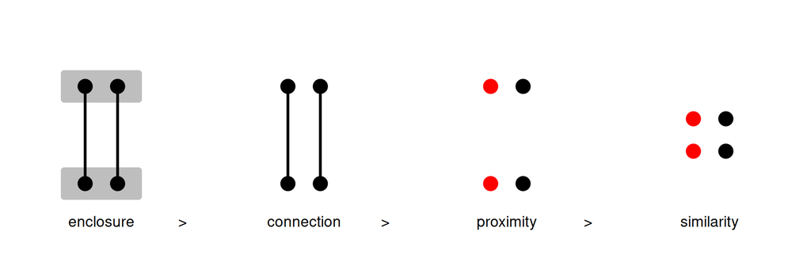

# Summary

- It makes sense to map **qualitative** data to **qualitative** visual features.
  - **Colour**, **shape**, and **position** are qualitative visual features.
  - Qualitative data can be visualised with:
    - points with different colours, positions, or shapes.
    - bars with different colours or positions.

# Summary

- **Colour**, **shape**, and **position** are appropriate visual features for representing qualitative data.
- **Colour** can be broken into **hue**, **chroma**, and **luminance**.
- **Hue** is only useful for **nominal** data.
- **Chroma** and **luminance** can be used for **ordinal** data.
- **Position** is a very effective and flexible visual feature.

# Summary

- The goal when mapping **qualitative** data is to create visual **groups** through:
  - **position** (proximity)
  - **shape** and **colour** (similarity)
  - **connectivity** (lines)
  - **enclosure** (polygons)

# Exercise

- We want to compare the count of offences for different `gender`s:
  - Are the counts for `Male` higher or lower than the counts for `Female` (on average)?

  ```r
  head(crimeGender)
  ```

  ```
    gender year count   pop     rate genderFactor   yearDate
  1   Male 2011  8808 95040 926.7677         Male 2011-06-30
  2 Female 2011  4207 90410 465.3246       Female 2011-06-30
  4   Male 2012  8031 95260 843.0611         Male 2012-06-30
  5 Female 2012  3513 90050 390.1166       Female 2012-06-30
  7   Male 2013  6768 94440 716.6455         Male 2013-06-30
  8 Female 2013  2976 89260 333.4080       Female 2013-06-30
  ```

# Exercise

- What type of data is `gender`?
- Which visual features would be appropriate for representing `gender`?
- Write {ggplot2} code to produce data visualisations that allow us to answer the questions of interest.

# Exercise

- The following code produces a simple bar chart

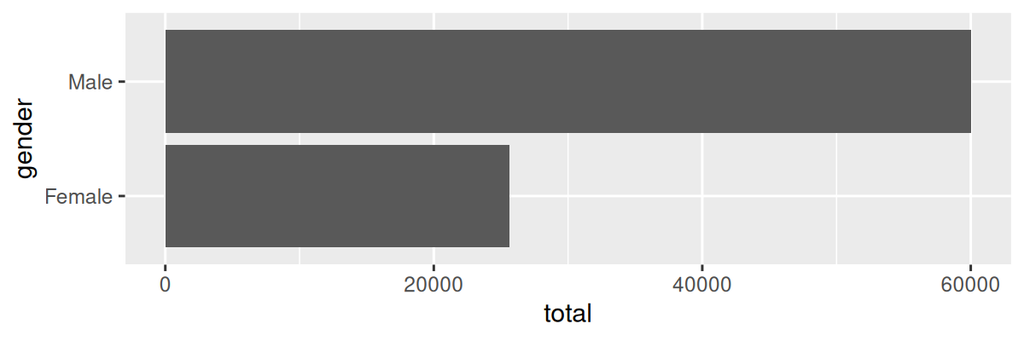

  ```r
  ggplot(crimeGenderTotal) +
      geom_col(aes(total, gender))
  ```

- Modify the code so that the Male bar is light blue and the Female bar is pink.

# Exercise

- Can you see anything wrong with this data visualisation?

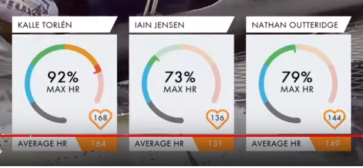